# Home Credit Default Risk Modeling

## Part 3: Interpretation

In this part, we try to explain the clustering results in the last part and determine the contribution of different variables to different classes. In this way, we can provide advice to the bank to decide whether to provide loans to its customers when the bank makes decisions, and they can focus on those variables that show the most important.

```python
import pandas as pd
import numpy as np
kmeans_train = pd.read_csv("kmeans_train.csv")
kmeans_train = kmeans_train.drop(['Unnamed: 0'],axis=1)
```

```python
from sklearn.preprocessing import LabelEncoder
import matplotlib as mpl
import matplotlib.pyplot as plt
import seaborn as sns
```

```python
Class0 = kmeans_train.loc[kmeans_train["Class"] == 0, ]
Class1 = kmeans_train.loc[kmeans_train["Class"] == 1, ]
Class2 = kmeans_train.loc[kmeans_train["Class"] == 2, ]
Class3 = kmeans_train.loc[kmeans_train["Class"] == 3, ]
Class4 = kmeans_train.loc[kmeans_train["Class"] == 4, ]
Class5 = kmeans_train.loc[kmeans_train["Class"] == 5, ]
```

```python
for i in range (len(kmeans_train.Class.unique())):
    count = len(kmeans_train.loc[kmeans_train["Class"] == i, ])
    print ("Class{}:{}".format(i, count))
```

```
Class0:53681
Class1:26163
Class2:75508
Class3:29148
Class4:48809
Class5:73911
```

```python
def perc_class_default(class_x, i):
    perc = len(class_x.loc[class_x["TARGET"] == 1, ])/len(class_x)
    return perc
```

```python
for i in range(len(kmeans_train.Class.unique())):
    x = kmeans_train.loc[kmeans_train["Class"] == i, ]
    print("the default rate of Class{} is {}".format(i, perc_class_default(x, i)))
```

```
the default rate of Class0 is 0.0822264860937762
the default rate of Class1 is 0.0478156174750602
the default rate of Class2 is 0.11095513058218996
the default rate of Class3 is 0.05948950185261424
the default rate of Class4 is 0.057182077075949106
the default rate of Class5 is 0.08437174439528622
```

Cluster 0 and cluster 5 have the default rate that is close to the average 0.08. And the average default rates of cluster 1 & 3 & 4 are lower than the average. However, we find that the people in cluster 2 are more likely to default, whose default rate is 0.11.

Next, we tried to interpret the results. We look at some features that contribute the five most to each of the principle components, such as ages, area size, AMT_credit, work city, etc.

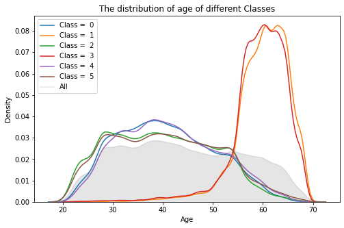

```python
sns.kdeplot(-(kmeans_train.loc[kmeans_train['Class'] == 0, 'DAYS_BIRTH']/365), label = 'Class =  0')

sns.kdeplot(-(kmeans_train.loc[kmeans_train['Class'] == 1, 'DAYS_BIRTH']/365), label = 'Class =  1')

sns.kdeplot(-(kmeans_train.loc[kmeans_train['Class'] == 2, 'DAYS_BIRTH']/365), label = 'Class =  2')

sns.kdeplot(-(kmeans_train.loc[kmeans_train['Class'] == 3, 'DAYS_BIRTH']/365), label = 'Class =  3')

sns.kdeplot(-(kmeans_train.loc[kmeans_train['Class'] == 4, 'DAYS_BIRTH']/365), label = 'Class =  4')

sns.kdeplot(-(kmeans_train.loc[kmeans_train['Class'] == 5, 'DAYS_BIRTH']/365), label = 'Class =  5')

sns.kdeplot(-(kmeans_train.loc[:, 'DAYS_BIRTH']/365), label = 'All', shade=True, alpha=.2, color = "grey")

plt.xlabel('Age'); plt.ylabel('Density'); plt.title('The distribution of age of different Classes');
```

We can see the distribution of contractors' age of different classes. We find that cluster 1 & 3 have more old people. As they have lower average default rates, we believe older people have lower average default rates than younger people.

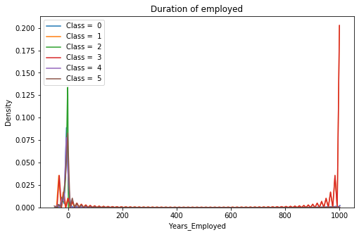

```python
plt.rcParams['figure.figsize'] = (8, 5)
sns.kdeplot((kmeans_train.loc[kmeans_train['Class'] == 0, 'DAYS_EMPLOYED']/365), label = 'Class =  0')

sns.kdeplot((kmeans_train.loc[kmeans_train['Class'] == 1, 'DAYS_EMPLOYED']/365), label = 'Class =  1')

sns.kdeplot((kmeans_train.loc[kmeans_train['Class'] == 2, 'DAYS_EMPLOYED']/365), label = 'Class =  2')

sns.kdeplot((kmeans_train.loc[kmeans_train['Class'] == 3, 'DAYS_EMPLOYED']/365), label = 'Class =  3')

sns.kdeplot((kmeans_train.loc[kmeans_train['Class'] == 4, 'DAYS_EMPLOYED']/365), label = 'Class =  4')

sns.kdeplot((kmeans_train.loc[kmeans_train['Class'] == 5, 'DAYS_EMPLOYED']/365), label = 'Class =  5')

plt.xlabel('Years_Employed'); plt.ylabel('Density'); plt.title('Duration of employed');
```

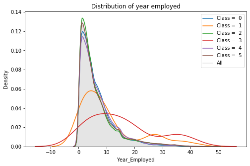

```python
plt.rcParams['figure.figsize'] = (8, 5)
sns.kdeplot(-(kmeans_train[kmeans_train['DAYS_EMPLOYED']<365243].loc[kmeans_train['Class'] == 0, 'DAYS_EMPLOYED'] / 365), label = 'Class =  0')

sns.kdeplot(-(kmeans_train[kmeans_train['DAYS_EMPLOYED']<365243].loc[kmeans_train['Class'] == 1, 'DAYS_EMPLOYED'] / 365), label = 'Class =  1')

sns.kdeplot(-(kmeans_train[kmeans_train['DAYS_EMPLOYED']<365243].loc[kmeans_train['Class'] == 2, 'DAYS_EMPLOYED'] / 365), label = 'Class =  2')

sns.kdeplot(-(kmeans_train[kmeans_train['DAYS_EMPLOYED']<365243].loc[kmeans_train['Class'] == 3, 'DAYS_EMPLOYED'] / 365), label = 'Class =  3')

sns.kdeplot(-(kmeans_train[kmeans_train['DAYS_EMPLOYED']<365243].loc[kmeans_train['Class'] == 4, 'DAYS_EMPLOYED'] / 365), label = 'Class =  4')

sns.kdeplot(-(kmeans_train[kmeans_train['DAYS_EMPLOYED']<365243].loc[kmeans_train['Class'] == 5, 'DAYS_EMPLOYED'] / 365), label = 'Class =  5')

sns.kdeplot(-(kmeans_train[kmeans_train['DAYS_EMPLOYED']<365243].loc[:, 'DAYS_EMPLOYED']/365), label = 'All', shade=True, alpha=.2, color = "grey")
plt.xlabel('Year_Employed'); plt.ylabel('Density'); plt.title('Distribution of year employed');
```

We can see the lines of clusters are closed to the line of mean except cluster 1 & 3. It is obvious as these two clusters have more older people so that in these two clusters they have more people who have worked more than 5 years.

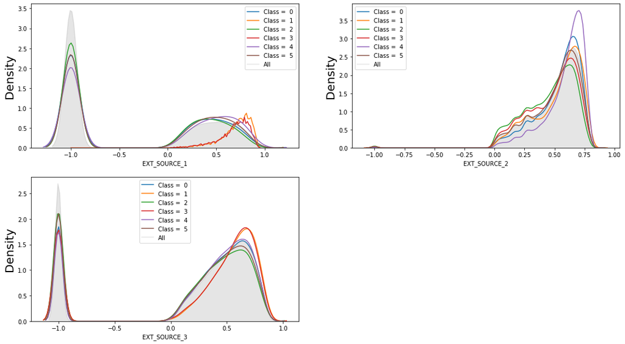

```python
plt.rcParams['figure.figsize'] = (18, 10)
f = plt.figure()
f.add_subplot(2,2,1)
sns.kdeplot((kmeans_train.loc[kmeans_train['Class'] == 0, 'EXT_SOURCE_1']), label = 'Class =  0')

sns.kdeplot((kmeans_train.loc[kmeans_train['Class'] == 1, 'EXT_SOURCE_1'] ), label = 'Class =  1')

sns.kdeplot((kmeans_train.loc[kmeans_train['Class'] == 2, 'EXT_SOURCE_1']), label = 'Class =  2')

sns.kdeplot((kmeans_train.loc[kmeans_train['Class'] == 3, 'EXT_SOURCE_1'] ), label = 'Class =  3')

sns.kdeplot((kmeans_train.loc[kmeans_train['Class'] == 4, 'EXT_SOURCE_1']), label = 'Class =  4')

sns.kdeplot((kmeans_train.loc[kmeans_train['Class'] == 5, 'EXT_SOURCE_1'] ), label = 'Class =  5')

sns.kdeplot((kmeans_train.loc[:, 'EXT_SOURCE_1'] ), label = 'All', shade=True, alpha=.2, color = "grey")

plt.xlabel('EXT_SOURCE_1'); plt.ylabel('Density', size=20);

f.add_subplot(2,2,2)
sns.kdeplot((kmeans_train.loc[kmeans_train['Class'] == 0, 'EXT_SOURCE_2']), label = 'Class =  0')

sns.kdeplot((kmeans_train.loc[kmeans_train['Class'] == 1, 'EXT_SOURCE_2'] ), label = 'Class =  1')

sns.kdeplot((kmeans_train.loc[kmeans_train['Class'] == 2, 'EXT_SOURCE_2']), label = 'Class =  2')

sns.kdeplot((kmeans_train.loc[kmeans_train['Class'] == 3, 'EXT_SOURCE_2'] ), label = 'Class =  3')

sns.kdeplot((kmeans_train.loc[kmeans_train['Class'] == 4, 'EXT_SOURCE_2']), label = 'Class =  4')

sns.kdeplot((kmeans_train.loc[kmeans_train['Class'] == 5, 'EXT_SOURCE_2'] ), label = 'Class =  5')

sns.kdeplot((kmeans_train.loc[:, 'EXT_SOURCE_2'] ), label = 'All', shade=True, alpha=.2, color = "grey")

plt.xlabel('EXT_SOURCE_2'); plt.ylabel('Density',size=20);

f.add_subplot(2,2,3)
sns.kdeplot((kmeans_train.loc[kmeans_train['Class'] == 0, 'EXT_SOURCE_3']), label = 'Class =  0')

sns.kdeplot((kmeans_train.loc[kmeans_train['Class'] == 1, 'EXT_SOURCE_3'] ), label = 'Class =  1')

sns.kdeplot((kmeans_train.loc[kmeans_train['Class'] == 2, 'EXT_SOURCE_3']), label = 'Class =  2')

sns.kdeplot((kmeans_train.loc[kmeans_train['Class'] == 3, 'EXT_SOURCE_3'] ), label = 'Class =  3')

sns.kdeplot((kmeans_train.loc[kmeans_train['Class'] == 4, 'EXT_SOURCE_3']), label = 'Class =  4')

sns.kdeplot((kmeans_train.loc[kmeans_train['Class'] == 5, 'EXT_SOURCE_3'] ), label = 'Class =  5')

sns.kdeplot((kmeans_train.loc[:, 'EXT_SOURCE_3'] ), label = 'All', shade=True, alpha=.2, color = "grey")

plt.xlabel('EXT_SOURCE_3'); plt.ylabel('Density', size=20);
```

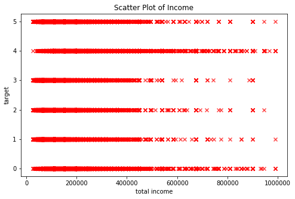

```python
kmeans_train_AMT = kmeans_train.loc[kmeans_train['AMT_INCOME_TOTAL']<1000000, : ]
plt.rcParams['figure.figsize'] = (8, 5)
plt.scatter(kmeans_train_AMT['AMT_INCOME_TOTAL'], kmeans_train_AMT['Class'], marker='x',
            color='red', alpha=0.7, label='x1 samples')
plt.xlabel('total income')
plt.ylabel('target')
plt.title('Scatter Plot of Income');
```

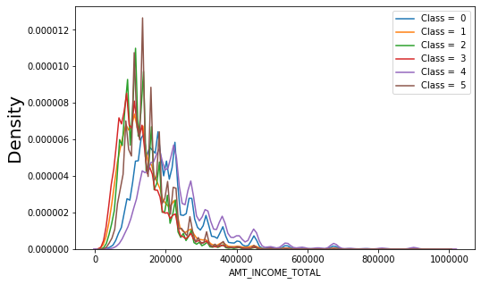

```python
sns.kdeplot((kmeans_train_AMT.loc[kmeans_train_AMT['Class'] == 0, 'AMT_INCOME_TOTAL']), label = 'Class =  0')

sns.kdeplot((kmeans_train_AMT.loc[kmeans_train_AMT['Class'] == 1, 'AMT_INCOME_TOTAL'] ), label = 'Class =  1')

sns.kdeplot((kmeans_train_AMT.loc[kmeans_train_AMT['Class'] == 2, 'AMT_INCOME_TOTAL']), label = 'Class =  2')

sns.kdeplot((kmeans_train_AMT.loc[kmeans_train_AMT['Class'] == 3, 'AMT_INCOME_TOTAL'] ), label = 'Class =  3')

sns.kdeplot((kmeans_train_AMT.loc[kmeans_train_AMT['Class'] == 4, 'AMT_INCOME_TOTAL']), label = 'Class =  4')

sns.kdeplot((kmeans_train_AMT.loc[kmeans_train_AMT['Class'] == 5, 'AMT_INCOME_TOTAL'] ), label = 'Class =  5')

plt.xlabel('AMT_INCOME_TOTAL'); plt.ylabel('Density', size=20);
```

Comparing the income distribution of different clusters, we find that cluster 4, which is one of the clusters with the lowest default, has a higher amount of total income. However, cluster 0, which has a normal average default rate, also has a high amount of total income and, cluster 3, which has low average default rate, has a low amount of total income. Thus, income cannot be an indicator of default rate.

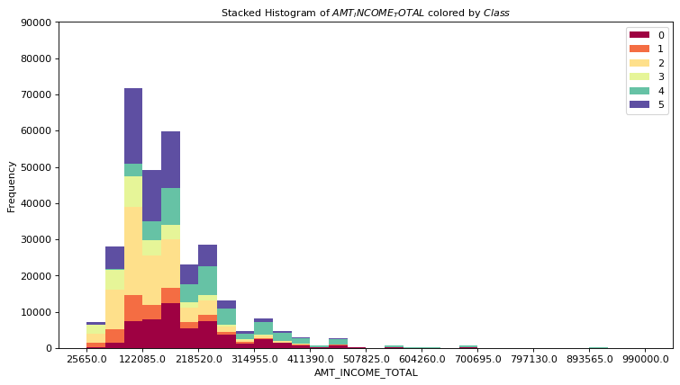

```python
x_var = 'AMT_INCOME_TOTAL'
groupby_var = 'Class'
df_agg = kmeans_train_AMT.loc[:, [x_var, groupby_var]].groupby(groupby_var)
vals = [kmeans_train_AMT[x_var].values.tolist() for i, kmeans_train_AMT in df_agg]

# Draw
plt.figure(figsize=(11,6), dpi= 80)
colors = [plt.cm.Spectral(i/float(len(vals)-1)) for i in range(len(vals))]
n, bins, patches = plt.hist(vals, 30, stacked=True, density=False, color=colors[:len(vals)])

# Decoration
plt.legend({group:col for group, col in zip(np.unique(kmeans_train_AMT[groupby_var]).tolist(), colors[:len(vals)])})
plt.title(f"Stacked Histogram of ${x_var}$ colored by ${groupby_var}$", fontsize=10)
plt.xlabel(x_var)
plt.ylabel("Frequency")
plt.ylim(0, 90000)
plt.xticks(ticks=bins[::3], labels=[round(b,1) for b in bins[::3]])
plt.show()
```

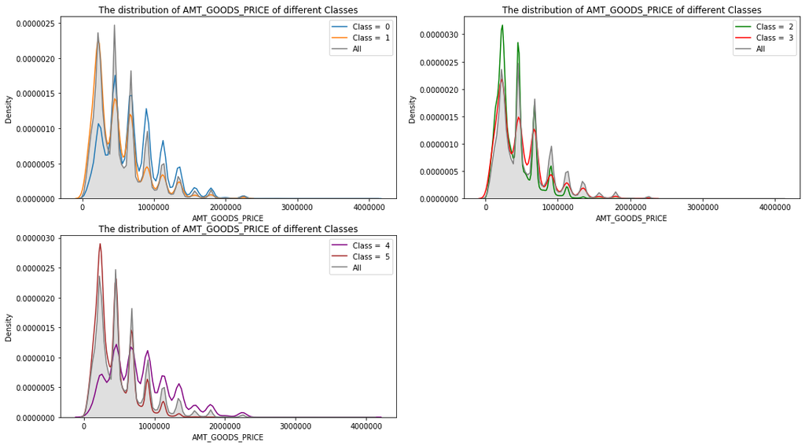

```python
#kmeans_train['AMT_GOODS_PRICE']
plt.rcParams['figure.figsize'] = (18, 10)
f = plt.figure()
f.add_subplot(2,2,1)
sns.kdeplot((kmeans_train.loc[kmeans_train['Class'] == 0, 'AMT_GOODS_PRICE']), label = 'Class =  0')

sns.kdeplot((kmeans_train.loc[kmeans_train['Class'] == 1, 'AMT_GOODS_PRICE']), label = 'Class =  1')

sns.kdeplot((kmeans_train.loc[:, 'AMT_GOODS_PRICE']), label = 'All', shade = True, color = "grey")
plt.xlabel('AMT_GOODS_PRICE'); plt.ylabel('Density'); plt.title('The distribution of AMT_GOODS_PRICE of different Classes');

f.add_subplot(2,2,2)

sns.kdeplot((kmeans_train.loc[kmeans_train['Class'] == 2, 'AMT_GOODS_PRICE']), label = 'Class =  2', color = 'g')

sns.kdeplot((kmeans_train.loc[kmeans_train['Class'] == 3, 'AMT_GOODS_PRICE']), label = 'Class =  3', color = 'r')

sns.kdeplot((kmeans_train.loc[:, 'AMT_GOODS_PRICE']), label = 'All', shade = True, color = "grey")
plt.xlabel('AMT_GOODS_PRICE'); plt.ylabel('Density'); plt.title('The distribution of AMT_GOODS_PRICE of different Classes');

f.add_subplot(2,2,3)

sns.kdeplot((kmeans_train.loc[kmeans_train['Class'] == 4, 'AMT_GOODS_PRICE']), label = 'Class =  4', color = 'purple')

sns.kdeplot((kmeans_train.loc[kmeans_train['Class'] == 5, 'AMT_GOODS_PRICE']), label = 'Class =  5', color = 'brown')

sns.kdeplot((kmeans_train.loc[:, 'AMT_GOODS_PRICE']), label = 'All', shade = True, color = "grey")
#sns.distplot(kmeans_train['AMT_GOODS_PRICE'] , bins = 30, color = "grey", label = 'All')
plt.xlabel('AMT_GOODS_PRICE'); plt.ylabel('Density'); plt.title('The distribution of AMT_GOODS_PRICE of different Classes');
```

AMT_GOODS_PRICE: For consumer loans it is the price of the goods for which the loan is given. We want to see how this feature is distributed in each cluster. We set clusters into 3 groups, two of which in order to clearly show the trends. We can see that clusters 0 & 4 tend to have higher prices of goods. Other clusters show similar fluctuation to all data points.

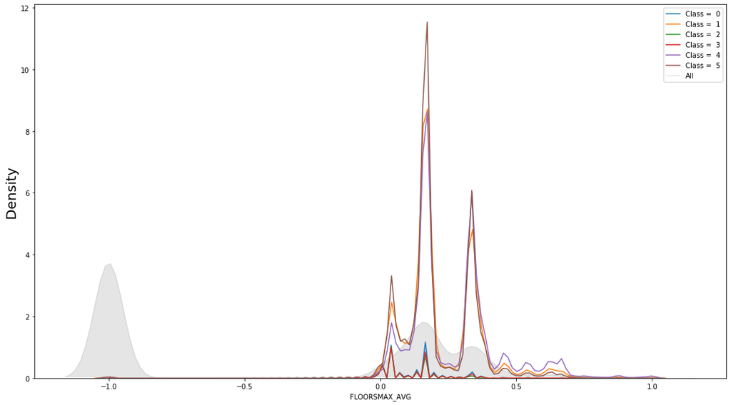

```python
#sns.kdeplot(kmeans_train['FLOORSMAX_AVG'])

sns.kdeplot((kmeans_train.loc[kmeans_train['Class'] == 0, 'FLOORSMAX_AVG']), label = 'Class =  0')

sns.kdeplot((kmeans_train.loc[kmeans_train['Class'] == 1, 'FLOORSMAX_AVG'] ), label = 'Class =  1')

sns.kdeplot((kmeans_train.loc[kmeans_train['Class'] == 2, 'FLOORSMAX_AVG']), label = 'Class =  2')

sns.kdeplot((kmeans_train.loc[kmeans_train['Class'] == 3, 'FLOORSMAX_AVG'] ), label = 'Class =  3')

sns.kdeplot((kmeans_train.loc[kmeans_train['Class'] == 4, 'FLOORSMAX_AVG']), label = 'Class =  4')

sns.kdeplot((kmeans_train.loc[kmeans_train['Class'] == 5, 'FLOORSMAX_AVG'] ), label = 'Class =  5')

sns.kdeplot((kmeans_train.loc[:, 'FLOORSMAX_AVG'] ), label = 'All', shade=True, alpha=.2, color = "grey")

plt.xlabel('FLOORSMAX_AVG'); plt.ylabel('Density', size=20);
```

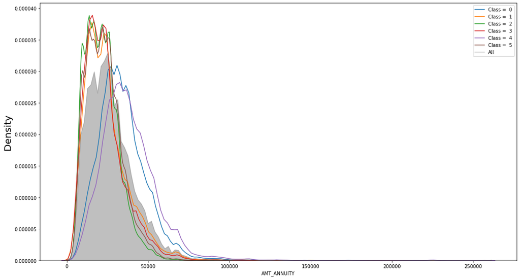

```python
sns.kdeplot((kmeans_train.loc[kmeans_train['Class'] == 0, 'AMT_ANNUITY']), label = 'Class =  0')

sns.kdeplot((kmeans_train.loc[kmeans_train['Class'] == 1, 'AMT_ANNUITY'] ), label = 'Class =  1')

sns.kdeplot((kmeans_train.loc[kmeans_train['Class'] == 2, 'AMT_ANNUITY']), label = 'Class =  2')

sns.kdeplot((kmeans_train.loc[kmeans_train['Class'] == 3, 'AMT_ANNUITY'] ), label = 'Class =  3')

sns.kdeplot((kmeans_train.loc[kmeans_train['Class'] == 4, 'AMT_ANNUITY']), label = 'Class =  4')

sns.kdeplot((kmeans_train.loc[kmeans_train['Class'] == 5, 'AMT_ANNUITY'] ), label = 'Class =  5')

sns.kdeplot((kmeans_train.loc[:, 'AMT_ANNUITY'] ), label = 'All', shade=True, alpha=.5, color = "grey")

plt.xlabel('AMT_ANNUITY'); plt.ylabel('Density', size=20);
```

AMT_ANNUITY is the loan annuity. It is obvious that cluster 0 & 4 has higher loan annuity.

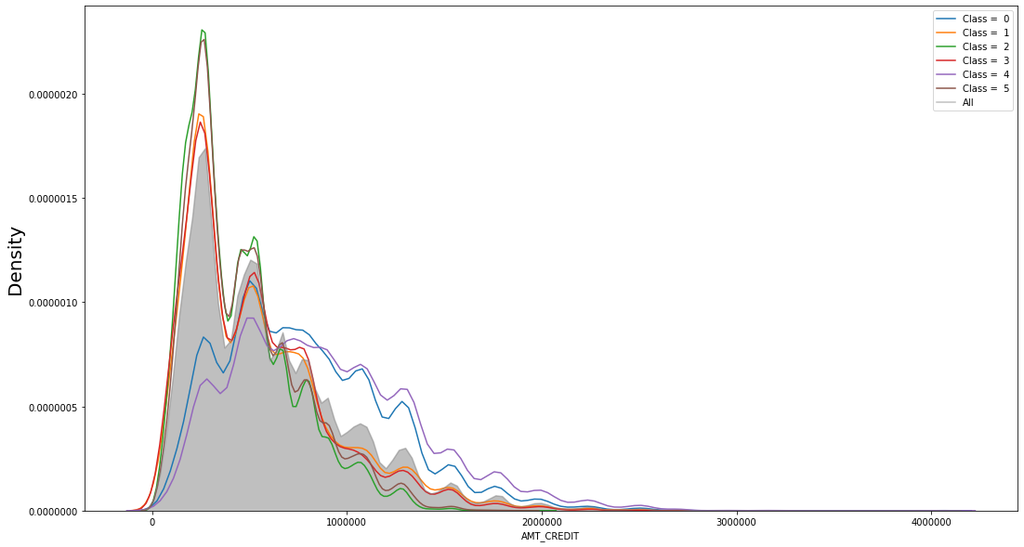

```python
sns.kdeplot((kmeans_train.loc[kmeans_train['Class'] == 0, 'AMT_CREDIT']), label = 'Class =  0')

sns.kdeplot((kmeans_train.loc[kmeans_train['Class'] == 1, 'AMT_CREDIT'] ), label = 'Class =  1')

sns.kdeplot((kmeans_train.loc[kmeans_train['Class'] == 2, 'AMT_CREDIT']), label = 'Class =  2')

sns.kdeplot((kmeans_train.loc[kmeans_train['Class'] == 3, 'AMT_CREDIT'] ), label = 'Class =  3')

sns.kdeplot((kmeans_train.loc[kmeans_train['Class'] == 4, 'AMT_CREDIT']), label = 'Class =  4')

sns.kdeplot((kmeans_train.loc[kmeans_train['Class'] == 5, 'AMT_CREDIT'] ), label = 'Class =  5')

sns.kdeplot((kmeans_train.loc[:, 'AMT_CREDIT'] ), label = 'All', shade=True, alpha=.5, color = "grey")

plt.xlabel('AMT_CREDIT'); plt.ylabel('Density', size=20);
```

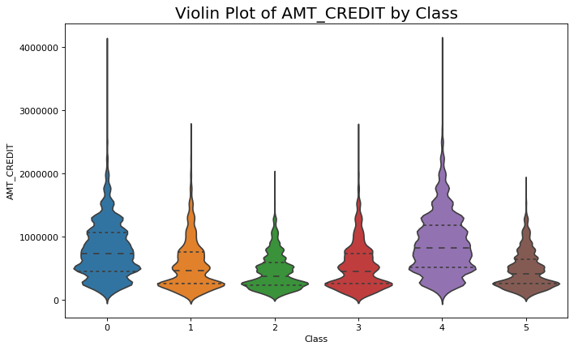

```python
plt.figure(figsize=(10,6), dpi= 80)
sns.violinplot(x='Class', y='AMT_CREDIT', data=kmeans_train, scale='width', inner='quartile')

# Decoration
plt.title('Violin Plot of AMT_CREDIT by Class', fontsize=18)
plt.show()
```

```python
def plot_stats(feature,TARGET,labely,label_rotation=False,horizontal_layout=True):
    temp = kmeans_train[feature].value_counts()
    df1 = pd.DataFrame({feature: temp.index,'Number of contracts': temp.values})

    # Calculate the percentage of target=1 per category value
    cat_perc = kmeans_train[[feature, TARGET]].groupby([feature],as_index=False).mean()
    #cat_perc.sort_values(by=TARGET, ascending=False, inplace=True)

    plt.figure(figsize=(4,5), dpi= 80)
    s = sns.barplot(x = feature, y=TARGET, order=cat_perc[feature], data=cat_perc)
    plt.ylabel('Percent of GENDER_M [%]', fontsize=15)
    plt.title(labely);

    plt.show();
```

[figure not shown]

```python
plot_stats('Class', 'FLAG_OWN_CAR_Y', 'FLAG_OWN_CAR_Y',False, True)
```

FLAG_OWN_CAR_Y: indicates the client owns a car. We can see that clusters 0 & 4 have a higher percentage of owning a car.

Our insights: here we find that the higher income, the more likely own a car. We cannot say if people have higher income or own a car, they have less default rate, as cluster 0 has the highest rate of owning a car but the average default rate is higher than overall average default rate. However, if people do not have a car or the income is not relatively high, they have more likelihood to default, as the people in clusters 2 & 5 the least likely own a car and have the highest average default rate among all the clusters.

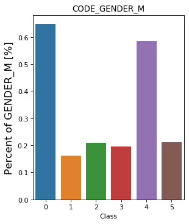

```python
plot_stats('Class', 'CODE_GENDER_M', 'CODE_GENDER_M',False, True)
```

This is the percentage of male in each cluster. The overall percentage of Male is 0.34, so that we can see that people in cluster 0 & 4 are most likely male. The other clusters have a higher percentage of females than total.

```python
len(kmeans_train.loc[kmeans_train["CODE_GENDER_M"]==1, :])/len(kmeans_train)
```

```
0.3416606991732309
```

```python
len(kmeans_train.loc[kmeans_train["CODE_GENDER_F"]==1, :])/len(kmeans_train)
```

```
0.6583262808410911
```

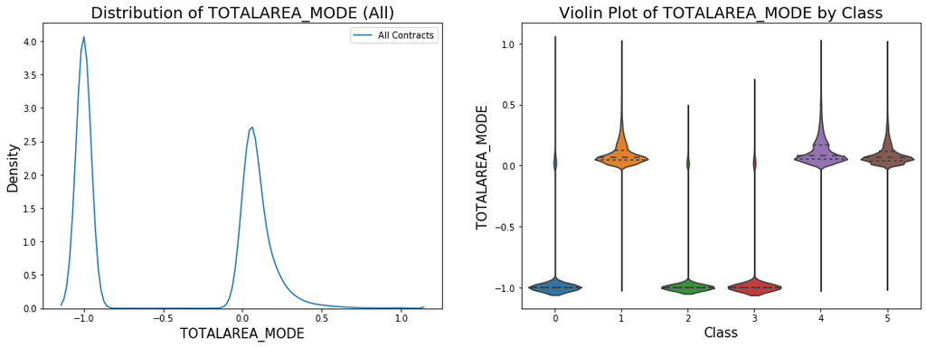

```python
plt.rcParams['figure.figsize'] = (18, 6)
f = plt.figure()
f.add_subplot(1,2,1)
sns.kdeplot(kmeans_train['TOTALAREA_MODE'], label = 'All Contracts')
plt.xlabel('TOTALAREA_MODE', size=15); plt.ylabel('Density', size=15);
plt.title('Distribution of TOTALAREA_MODE (All)', fontsize=18)

f.add_subplot(1,2,2)
sns.violinplot(x='Class', y='TOTALAREA_MODE', data=kmeans_train, scale='width', inner='quartile')
plt.xlabel('Class', size=15); plt.ylabel('TOTALAREA_MODE', size=15);
# Decoration
plt.title('Violin Plot of TOTALAREA_MODE by Class', fontsize=18)
#plt.show()
```

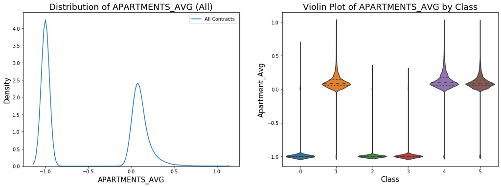

```python
plt.rcParams['figure.figsize'] = (18, 6)
f = plt.figure()
f.add_subplot(1,2,1)
sns.kdeplot(kmeans_train['APARTMENTS_AVG'], label = 'All Contracts')
plt.xlabel('APARTMENTS_AVG', size=15); plt.ylabel('Density', size=15);
plt.title('Distribution of APARTMENTS_AVG (All)', fontsize=18)

f.add_subplot(1,2,2)
sns.violinplot(x='Class', y='APARTMENTS_AVG', data=kmeans_train, scale='width', inner='quartile')
plt.xlabel('Class', size=15); plt.ylabel('Apartment_Avg', size=15);
# Decoration
plt.title('Violin Plot of APARTMENTS_AVG by Class', fontsize=18)
#plt.show()
```

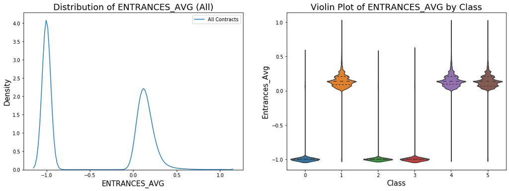

```python
plt.rcParams['figure.figsize'] = (18, 6)
f = plt.figure()
f.add_subplot(1,2,1)
sns.kdeplot(kmeans_train['ENTRANCES_AVG'], label = 'All Contracts')
plt.xlabel('ENTRANCES_AVG', size=15); plt.ylabel('Density', size=15);
plt.title('Distribution of ENTRANCES_AVG (All)', fontsize=18)

f.add_subplot(1,2,2)
sns.violinplot(x='Class', y='ENTRANCES_AVG', data=kmeans_train, scale='width', inner='quartile')
plt.xlabel('Class', size=15); plt.ylabel('Entrances_Avg', size=15);
# Decoration
plt.title('Violin Plot of ENTRANCES_AVG by Class', fontsize=18)
#plt.show()
```

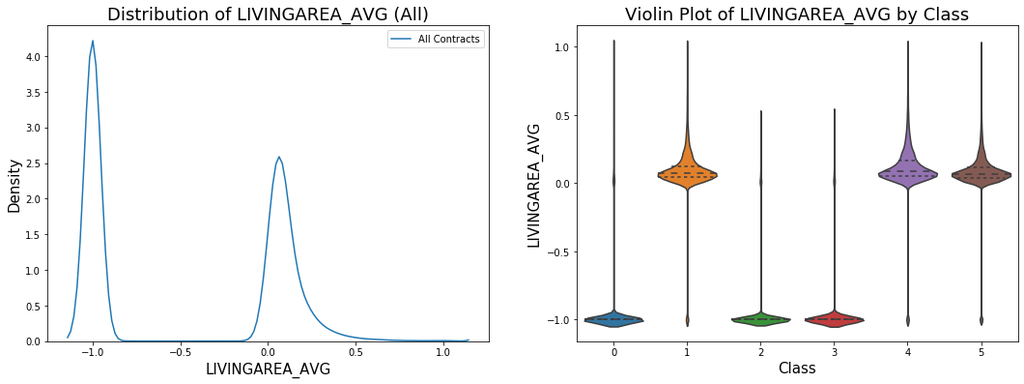

```python
plt.rcParams['figure.figsize'] = (18, 6)
f = plt.figure()
f.add_subplot(1,2,1)
sns.kdeplot(kmeans_train['LIVINGAREA_AVG'], label = 'All Contracts')
plt.xlabel('LIVINGAREA_AVG', size=15); plt.ylabel('Density', size=15);
plt.title('Distribution of LIVINGAREA_AVG (All)', fontsize=18)

f.add_subplot(1,2,2)
sns.violinplot(x='Class', y='LIVINGAREA_AVG', data=kmeans_train, scale='width', inner='quartile')
plt.xlabel('Class', size=15); plt.ylabel('LIVINGAREA_AVG', size=15);
# Decoration
plt.title('Violin Plot of LIVINGAREA_AVG by Class', fontsize=18)
#plt.show()
```

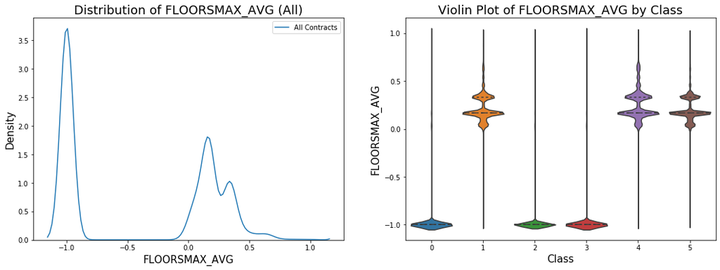

```python
plt.rcParams['figure.figsize'] = (18, 6)
f = plt.figure()
f.add_subplot(1,2,1)
sns.kdeplot(kmeans_train['FLOORSMAX_AVG'], label = 'All Contracts')
plt.xlabel('FLOORSMAX_AVG', size=15); plt.ylabel('Density', size=15);
plt.title('Distribution of FLOORSMAX_AVG (All)', fontsize=18)

f.add_subplot(1,2,2)
sns.violinplot(x='Class', y='FLOORSMAX_AVG', data=kmeans_train, scale='width', inner='quartile')
plt.xlabel('Class', size=15); plt.ylabel('FLOORSMAX_AVG', size=15);
# Decoration
plt.title('Violin Plot of FLOORSMAX_AVG by Class', fontsize=18)
#plt.show()
```

We can see that the above five features that contribute to principal component 1 are all the normalized information about building where the client lives. There are many records showing the value of "-1", which indicate that they were missing in the original dataset and were filled with "-1" in the data processing step.

We found that their characteristics are very similar in the same cluster. We can conclude that clusters 1 & 4 & 5 have values of these property features. However, the other clusters 0 & 2 & 3 are most likely to have missing values in these variables. It is notably that cluster 2 has a higher default rate and less likely to fill this information.

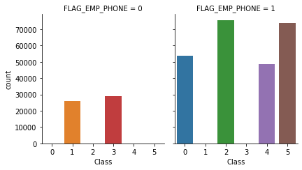

```python
g = sns.catplot("Class", col="FLAG_EMP_PHONE", col_wrap=4,
                data=kmeans_train[kmeans_train.FLAG_EMP_PHONE.notnull()],
                kind="count", height=3.5, aspect=.8,
                )

#fig.suptitle('sf')
plt.show()
```

For FLAG_EMP_PHONE we can see that people in clusters 1 & 3 are less likely to have their work phone information, and this is correlated with age variable. We think it is meaningful because they are older and most likely not employed.

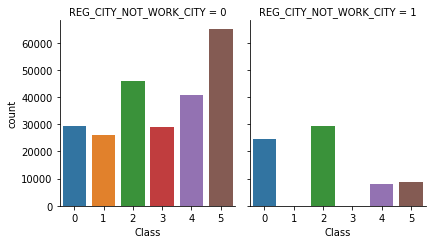

```python
var= 'REG_CITY_NOT_WORK_CITY'
g = sns.catplot("Class", col = var, col_wrap=4,
                data=kmeans_train[kmeans_train.REG_CITY_NOT_WORK_CITY.notnull()],
                kind="count", height=3.5, aspect=.8,
                )

#fig.suptitle('sf')
plt.show()
```

REG_CITY_WORK_CITY: flag if client's permanent address does not match work address (1=different, 0=same, at city level). For this graph, we can see a higher percentage of contractors in cluster 0 & 2 work in a different city to their permanent address.

Then, in order to have more knowledge of this feature, we calculate the default rate of people whose permanent address match work address and whose not match in cluster 2. We find 10.1% of those who have the same work address as their permanent address and 12.6% of those different in cluster 2. It is interesting that cluster 2 has the default rate of 11.1%. Thus, we think this feature is important for predicting the default behavior.

```python
A = Class2.loc[Class2['REG_CITY_NOT_WORK_CITY'] == 1 , :]
perc_class_default(A)
```

```
0.12687125748502995
```

```python
B = Class2.loc[Class2['REG_CITY_NOT_WORK_CITY'] == 0 , :]
perc_class_default(B)
```

```
0.10081099835198196
```

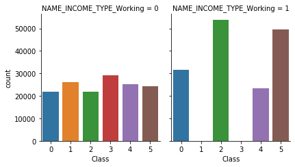

```python
var= 'NAME_INCOME_TYPE_Working'
g = sns.catplot("Class", col = var, col_wrap=4,
                data=kmeans_train[kmeans_train.NAME_INCOME_TYPE_Working.notnull()],
                kind="count", height=3.5, aspect=.8,
                )

#fig.suptitle('sf')
plt.show()
```

This indicates whether their income is from working or other types. We can see that people in cluster 1 and 3 tend to have incomes not from working. This makes sense because they are older so that they may not be employed at this stage.

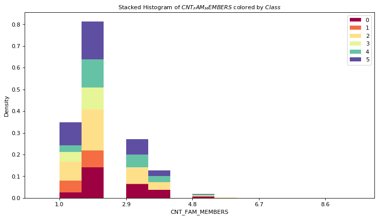

```python
#kmeans_train['CNT_FAM_MEMBERS']
x_var = 'CNT_FAM_MEMBERS'
groupby_var = 'Class'
df_agg = kmeans_train.loc[:, [x_var, groupby_var]].groupby(groupby_var)
vals = [kmeans_train[x_var].values.tolist() for i, kmeans_train in df_agg]

# Draw
plt.figure(figsize=(11,6), dpi= 80)
colors = [plt.cm.Spectral(i/float(len(vals)-1)) for i in range(len(vals))]
n, bins, patches = plt.hist(vals, 30, stacked=True, density=True, color=colors[:len(vals)])

# Decoration
plt.legend({group:col for group, col in zip(np.unique(kmeans_train[groupby_var]).tolist(), colors[:len(vals)])})
plt.title(f"Stacked Histogram of ${x_var}$ colored by ${groupby_var}$", fontsize=10)
plt.xlabel(x_var)
plt.ylabel("Density")
plt.xticks(ticks=bins[::3], labels=[round(b,1) for b in bins[::3]])
plt.xlim(0, 10)
plt.show()
```

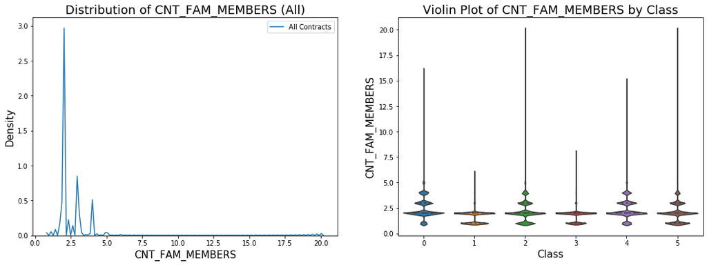

```python
plt.rcParams['figure.figsize'] = (18, 6)
f = plt.figure()
f.add_subplot(1,2,1)
sns.kdeplot(kmeans_train['CNT_FAM_MEMBERS'], label = 'All Contracts')
plt.xlabel('CNT_FAM_MEMBERS', size=15); plt.ylabel('Density', size=15);
plt.title('Distribution of CNT_FAM_MEMBERS (All)', fontsize=18)

f.add_subplot(1,2,2)
sns.violinplot(x='Class', y='CNT_FAM_MEMBERS', data=kmeans_train, scale='width', inner='quartile')
plt.xlabel('Class', size=15); plt.ylabel('CNT_FAM_MEMBERS', size=15);
# Decoration
plt.title('Violin Plot of CNT_FAM_MEMBERS by Class', fontsize=18)
#plt.show()
```

```python
kmeans_train.loc[kmeans_train['CNT_FAM_MEMBERS']>=16, :]
```

|  | TARGET | CNT_CHILDREN | AMT_INCOME_TOTAL | AMT_CREDIT | AMT_ANNUITY | AMT_GOODS_PRICE | REGION_POPULATION_RELATIVE | DAYS_BIRTH | DAYS_EMPLOYED | DAYS_REGISTRATION | ... | WALLSMATERIAL_MODE_Block | WALLSMATERIAL_MODE_Mixed | WALLSMATERIAL_MODE_Monolithic | WALLSMATERIAL_MODE_Others | WALLSMATERIAL_MODE_Panel | WALLSMATERIAL_MODE_Stone, brick | WALLSMATERIAL_MODE_Wooden | EMERGENCYSTATE_MODE_No | EMERGENCYSTATE_MODE_Yes | Class |
| --- | --- | --- | --- | --- | --- | --- | --- | --- | --- | --- | --- | --- | --- | --- | --- | --- | --- | --- | --- | --- | --- |
| 155230 | 0 | 19 | 112500.0 | 269550.0 | 13891.5 | 225000.0 | 0.007020 | -11057 | -1853 | -3096.0 | ... | 0 | 0 | 0 | 0 | 0 | 0 | 0 | 0 | 0 | 2 |
| 183723 | 0 | 14 | 45000.0 | 810000.0 | 23814.0 | 810000.0 | 0.008625 | -20308 | 365243 | -12416.0 | ... | 0 | 0 | 0 | 0 | 0 | 0 | 0 | 0 | 0 | 0 |
| 265540 | 0 | 19 | 112500.0 | 135000.0 | 8788.5 | 135000.0 | 0.015221 | -10297 | -896 | -4733.0 | ... | 0 | 0 | 0 | 0 | 1 | 0 | 0 | 1 | 0 | 5 |
| 267751 | 0 | 14 | 54000.0 | 604152.0 | 25596.0 | 540000.0 | 0.011703 | -15463 | -540 | -6222.0 | ... | 0 | 0 | 0 | 0 | 0 | 1 | 0 | 1 | 0 | 0 |

4 rows × 218 columns

### Summary Characteristic of Each Cluster:

Cluster 0 (8.2% default rate): higher amount of income; higher percentage of owning a car; higher percentage of male; more likely to have missing value of housing information; higher average credit amount; higher amount of goods price; having the work phone; different working city to permanent address; abnormal amount of family members.

Cluster 1 (4.8% default rate): higher percentage of old people (aged 60 or higher); less likely to have information about work phones; longer years of employment; higher credit score at external source 1 & 3.

Cluster 2 (11.1% default rate): more likely to have missing value of housing information; different working city to permanent address; unnormal amount of family members; lower average credit amount.

Cluster 3 (5.9% default rate): higher percentage of old people (aged 60 or higher); more likely to have missing value of housing information; less likely to have information about work phones; higher credit at external source 1 & 3; longer year of employment.

Cluster 4 (5.7% default rate): high average income; high percentage of owning a car; high average credit amount; better credit at external source 2; higher percentage of male; higher amount of goods price.

Cluster 5 (8.4% default rate): normal average default rate; low percentage of owning a car; low average credit amount. Similar characteristics as cluster 2 except for that it has filled property information.

Finally , we suggest that our client attach great importance to these variables. Financial Institutes can classify future borrowers according to these characteristics, and evaluate their default risk.